# Analyzing the relationships between variables monitored at AIM sites in WA and the number of dams upstream

# Biodiversity and Riparian Habitat Quality Correlation Plot

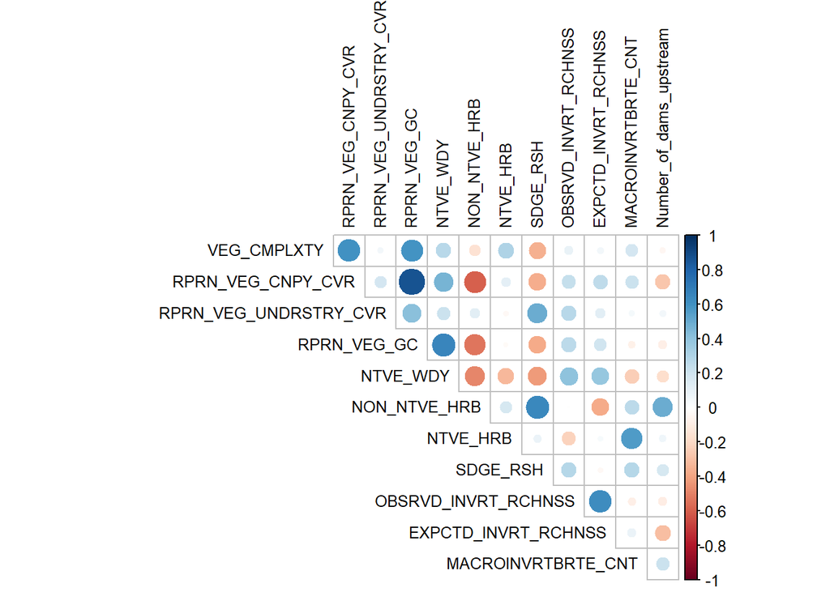

# Watershed Function and Instream Habitat Quality Correlation Plot

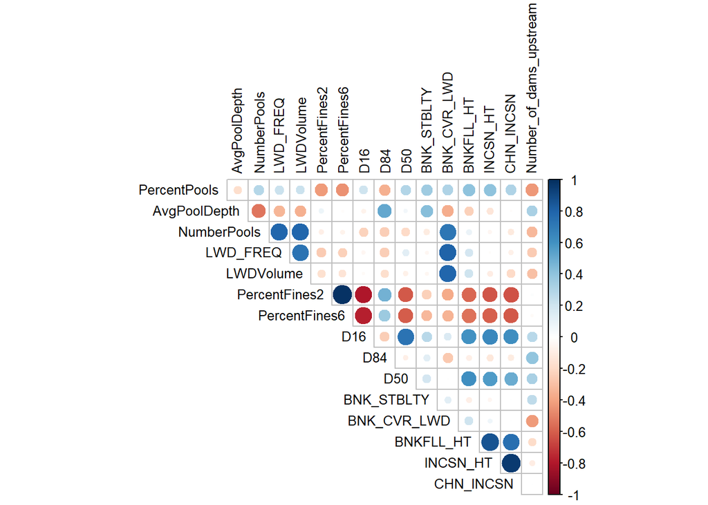

# Results of Correlation Plots

# Summary and Conclusions

Washington’s rivers are saturated with dams. The number of dams upstream of a sample site correlated with metrics that negatively influence water quality. However, because of the small sample size and since the AIM sites are one-off sampling occurrences, the sites provide a wealth of information but not a clear way to examine or compare data over time. Therefore it is difficult to say whether the poor water quality is caused by the dams, or if both are side-effects of highly human disturbed ecosystems.

# Next Steps

The initial analyses we ran prepared us to further investigate the data. We plan to: - Run an AIC to choose the most influential variables - Run regression with the AIC determined variables - Run a regression that includes stream order, dam type, number of dams upstream, and distance to dam with selected AIM variable as the dependent variable - Calculate flowline distances with NHDtoolsplus - Compare on AIM variables between sample site catchments on the basis of # of dams, dams / square mile, and flowline distance to dams